# STAT380_HW2

Mia Iceland

January 25, 2024”

## Instructions

In class, we covered the basics of data wrangling using some of the basic `dplyr` verbs. The activities that follow are meant to provide further practice with these functions. This assignment will also include some data visualization review.

In order to access the textbook, please see https://mdsr-book.github.io/mdsr3e/.

At the conclusion to the activity, you should upload

1. your .html file named LastnameFirstInitial_STAT380_HW2.html
2. your .Rmd file named LastnameFirstInitial_STAT380_HW2.Rmd

## Learning Objectives

This assignment address aspects of the following learning objectives.

1. Students will be able to load datasets from R packages and external sources into the R environment.
2. Students will be able to identify R functions for and perform data wrangling tasks such as filtering observations based on a criterion, creating new variables, and restructuring data.
3. Given one or more variables, students will be able to identify appropriate types of visualizations for exploring the distribution of the variable or the relationship between the variables visually.
4. Given a research question, students will be able to create and customize an appropriate visualization using statistical software.
5. Given one or more variables, students will be able to calculate summary statistics for exploring the distribution of the variable or the relationship between the variables numerically.
6. Given a visualization and summary statistics, students will be able to describe the insights gained from the information.

## Front Matter - Clean Environment, Load Libraries, User Defined Functions

```r
rm(list = ls())
#Add libraries as needed
library(tidyverse)
library(Lahman)
L2_insurance_dataset <- read.csv("L02_Insurance_m.csv")
```

## 1. Chapter 4.4 Exercises - Problem 3

The problem with this pipeline is that the filter statement is after the summarize statement and not before it. The summarize statement aggregates the rows to find the mean miles per gallon for each cylinder. Putting the filter statement for the ‘am’ variable after this aggregation would not work.

## 2. Chapter 4.4 Exercises - Problem 5

The real world meaning of the variable ‘N’ is the number of rows/cases for each type of cylinder.

## 3. Chapter 4.4 Exercises - Problem 6

1. summarize()
2. mutate()
3. arrange()
4. filter()
5. select()

## 4. Chapter 4.4 Exercises - Problem 4 - Define two new variables in the `Teams` data frame in the `Lahman` package and create the indicated plots.

- This problem requires the `Lahman` package. From the `Lahman` packages, use the `Teams` data frame.
- This problem is not identical to Problem 4, but it is similar. I have tried to provide more details for you to help those who may not be familiar with baseball.
- This question might be a bit tricky, especially if you are not familiar with baseball. HINT: In baseball, there are four types of hits: a single, a double, a triple, and a homerun. The dataset contains variables representing the total number of hits (`H`), the number of doubles (`X2B`), the number of triples (`X3B`), and the number of homeruns (`HR`), but not the number of singles. If you know all but one piece, how can you find the missing piece?

To find the number of singles add up the number of doubles, triples, and homeruns and subtract the total number of hits by the calculated sum.

1. Define batting average (`BA`). Batting average is the ratio of hits (`H`) to at-bats (`AB`).

```r
Team <-
  Teams %>%
    mutate(BA = H / AB)
```

2. Define slugging percentage (`SLG`). Slugging percentage is total bases earned by hits divided by at-bats. You will have to create a new variable that represents the total bases. To compute total bases, you get 1 for a single, 2 for a double, 3 for a triple, and 4 for a home run. For example, if a team has 11 total hits (5 singles, 3 doubles, 1 triple, and 2 home runs), then the team would have `5*1 + 3*2 + 1*3 + 2*4 = 22` total bases. The numbers in the dataset are larger, but this is just an example.

```r
Team1 <-
  Teams %>%
    mutate(BA = H / AB,
      without_singles = X2B + X3B + HR,
      singles = H - without_singles,
      total_bases = singles + 2 * X2B + 3 * X3B + 4 * HR,
      SLG = total_bases / AB)
```

3. In order to show that the calculations in Part a. and Part b. were correct, display the first 10 rows of data. Include only the 5 variables: `yearID`, `teamID`, `franchID`, `BA` and `SLG`. In order to see if your answers are correct, the first row should have the values 1871, BS1, BNA, 0.310, and 0.422. If you are not getting these answers, it will affect almost all future answers so be sure to get help from your instructor or someone else.

```r
Team1 %>%
  select(yearID, teamID, franchID, BA, SLG) %>%
  head(10)
```

```
##    yearID teamID franchID        BA       SLG
## 1    1871    BS1      BNA 0.3104956 0.4220117
## 2    1871    CH1      CNA 0.2700669 0.3737458
## 3    1871    CL1      CFC 0.2765599 0.3912310
## 4    1871    FW1      KEK 0.2386059 0.2935657
## 5    1871    NY2      NNA 0.2870370 0.3497151
## 6    1871    PH1      PNA 0.3200625 0.4348165
## 7    1871    RC1      ROK 0.2644788 0.3638996
## 8    1871    TRO      TRO 0.3076923 0.4174679
## 9    1871    WS3      OLY 0.2771619 0.3688101
## 10   1872    BL1      BLC 0.2928821 0.3745624
```

4. Plot out the `SLG` (y-axis) as a function of `yearID` (x-axis), showing the individual teams and a smooth curve (i.e., use the loess smoother, which is the default, but remove the error/confidence interval bounds). NOTE: There should be a single smooth curve, not one for each team. When the instruction states that you should show individual teams, this simply means that each term should be shown as a point on the plot. You do NOT have to label each team with text, colors, shapes, etc.

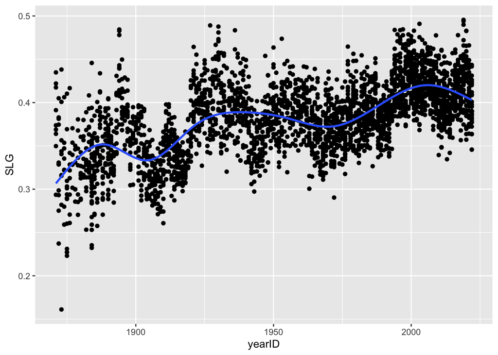

```r
ggplot(data = Team1, mapping = aes(x = yearID, y = SLG)) +
  geom_point() +
  geom_smooth(se = FALSE)
```

5. Same as Part d., but plot `BA` as a function of year.

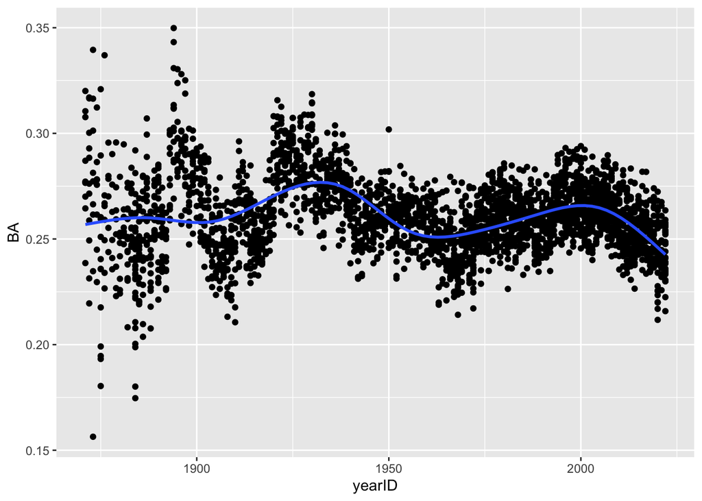

```r
ggplot(data = Team1, mapping = aes(x = yearID, y = BA)) +
  geom_point() +
  geom_smooth(se = FALSE)
```

## 5. Chapter 4.4 Exercises - Problem 7 - Find top teams based on sluggling percentage.

1. Using the `Teams` data frame in the Lahman package, display the top-5 teams ranked in terms of slugging percentage (`SLG` which you computed in the previous question) in Major League Baseball history. Display the top 5 teams but only include the following variables: `yearID`, `lgID`, `teamID`, `franchID`, `SLG`.

```r
Team1 <-
  Teams %>%
    mutate(BA = H / AB,
      without_singles = X2B + X3B + HR,
      singles = H - without_singles,
      total_bases = singles + 2 * X2B + 3 * X3B + 4 * HR,
      SLG = total_bases / AB)

Team1 %>%
  select(yearID, teamID, franchID, BA, SLG) %>%
  arrange(desc(SLG)) %>%
  head(5)
```

```
##   yearID teamID franchID        BA       SLG
## 1   2019    HOU      HOU 0.2740068 0.4954570
## 2   2019    MIN      MIN 0.2698883 0.4940684
## 3   2003    BOS      BOS 0.2889582 0.4908996
## 4   2019    NYA      NYY 0.2674190 0.4898800
## 5   1927    NYA      NYY 0.3074621 0.4890593
```

- NOTE1: A higher `SLG` is better. So you are looking for the 5 highest values of `SLG`.
- NOTE2: When finding the “top 5 teams”, the same team from two different years would could as 2. For instance, you may find the New York Yankees (`franchID = NYY`) from 2019 and 1927 make up two of the top 5 teams.
2. Repeat part a. using teams since 1969 (i.e, “since 1969” means 1969, 1970, 1971, …, 2021).

```r
Team1 <-
  Teams %>%
    mutate(BA = H / AB,
      without_singles = X2B + X3B + HR,
      singles = H - without_singles,
      total_bases = singles + 2 * X2B + 3 * X3B + 4 * HR,
      SLG = total_bases / AB)

Team1 %>%
  select(yearID, teamID, franchID, BA, SLG) %>%
  filter(yearID > 1968) %>%
  arrange(desc(SLG)) %>%
  head(5)
```

```
##   yearID teamID franchID        BA       SLG
## 1   2019    HOU      HOU 0.2740068 0.4954570
## 2   2019    MIN      MIN 0.2698883 0.4940684
## 3   2003    BOS      BOS 0.2889582 0.4908996
## 4   2019    NYA      NYY 0.2674190 0.4898800
## 5   1997    SEA      SEA 0.2803705 0.4845030
```

## 6. Chapter 4.4 Exercises - Problem 8 - Using the `Teams` data frame in the `Lahman` package, create more plots

1. Plot `SLG` (y axis) as a function of `yearID` (x-axis) since 1954 conditioned by league (American vs. National, see `lgID`). Include the loess smoother (with or without error/confidence intervals).
- NOTE: To condition on league, you could either use faceting or add color; however, adding color will make the comparison easier to make in Part b.

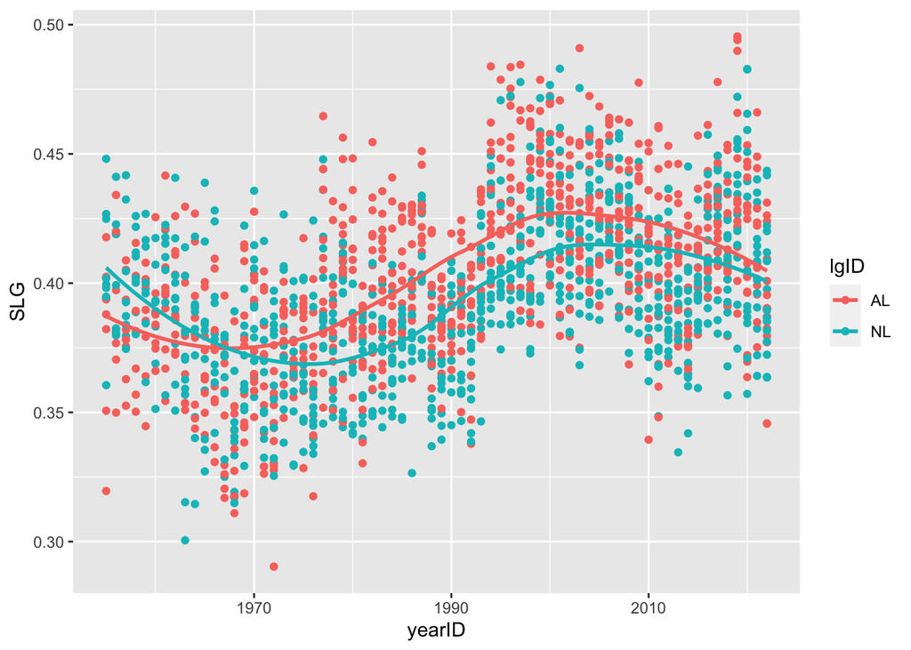

```r
Team2 <-
  Team1 %>%
    filter(yearID > 1954)

ggplot(data = Team2, mapping = aes(x = yearID, y = SLG, color = lgID)) +
  geom_point() +
  geom_smooth(se = FALSE)
```

2. Is slugging percentage typically higher in the American League (AL) or the National League (NL)?

The slugging percentage is typically higher in the American League than in the National League between 1954 and present.

3. (Ungraded) If you are familiar with baseball, can you explain why you see this pattern in the plot from Part a.?

I am not familiar with baseball sadly.

## 7. Recreate plot shown in Example 5a of Lecture 2 notes (side-by-side boxplots with the mean added to the boxplots.)

- HINT: In in the original `ggplot` command, specify a dataset contains the smokers over 40. In a later command in which you add another layer to the plot, specify a second dataset that has the mean associated with each region.

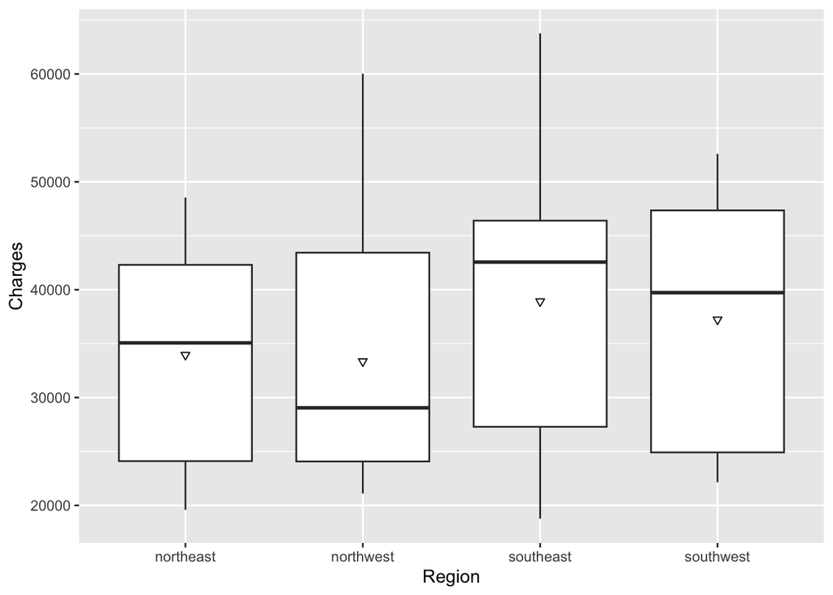

```r
#data of smokers over 40 years old
Ins <-
  L2_insurance_dataset %>%
    filter(age > 40 & smoker == "yes")

Ins1 <-
  L2_insurance_dataset %>%
    filter(age > 40 & smoker == "yes") %>%
    group_by(region) %>%
    summarize(mean = mean(charges, na.rm = TRUE))

#create the plot
ggplot(data = Ins, mapping = aes(x = region, y = charges)) +
  geom_boxplot() +
  labs(x = "Region", y = "Charges") +
  geom_point(data = Ins1, aes(x = region, y = mean), shape = 6)
```